# Typologie des compétences numériques des Français

Suppression des ind qui ont répondu ‘nsp’,‘rdr’ ou ‘comprend.pas’ 3 fois ou +

Laurent Mell, Nicolas Deporte &co

14 novembre 2017

### Préparation de la base pour l’analyse

On a un problème avec les individus qui ont répondu ‘nsp’,‘rdr’ ou ‘comprend.pas’. C’est un comportement “inhabituel” par rapport à la norme des réponses, qui va générer la création d’axes (dans les 1ers axes) dédiés à ‘nsp’,‘rdr’ ou ‘comprend.pas’ et ensuite générer des classes autour de ces réponses et brouiller la classification.

Il faut donc traiter ces réponses préalablement à l’AFM + HCPC.

2 solutions :

- soit on supprime simplement tous les individus qui ont répondu au moins une fois ‘nsp’,‘rdr’ ou ‘comprend.pas’. On enlève alors 402 répondants.
- soit on supprime seulement les individus qui ont répondu trop souvent ‘nsp’,‘rdr’ ou ‘comprend.pas’, par exemple, tous ceux qui ont répondu 3 fois ou plus ‘nsp’,‘rdr’ ou ‘comprend.pas’. On enlève alors seulement 146 répondants. (Si on enlève tous ceux qui ont répondu 2 fois ou plus ‘nsp’,‘rdr’ ou ‘comprend.pas’, on enlève 204 répondants.)

Ici on réalise la solution 2.

La préparation est faite !

### AFM

```r
#load(file="skill_affine.Rdata")
resMFA <- MFA(skill, group=c(15,1,4,5,4,4,4), type=c("n","c","n","n","n","n","n"), ncp=43, name.group=c("Illustratives","Pondération","Comp. opérationnelles","Comp. informationnelles","Comp. sociales","Comp. créatives","Comp. mobiles"), num.group.sup=c(1,2), graph=FALSE, row.w=skill$poids)
# ou ncp=43 -> 70% de l'inertie initiale est conservée (pour la CAH)
#summary(resMFA)

#save(resMFA, file="resMFA_affine.Rdata")
```

### Histogramme des valeurs propres

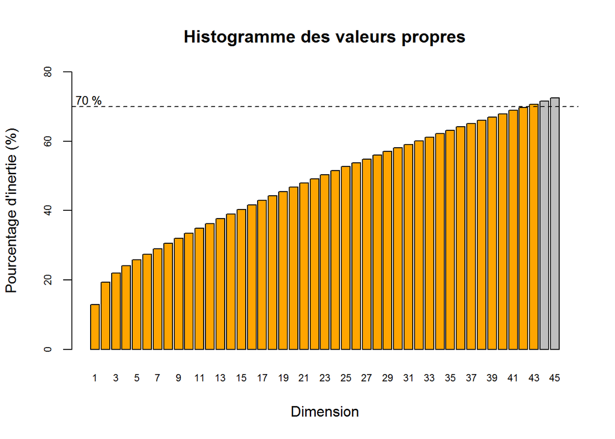

```r
load(file="resMFA_affine.Rdata")
barplot(resMFA$eig[1:45,3], main="Histogramme des valeurs propres",
        xlab="Dimension", ylab="Pourcentage d'inertie (%)", cex.axis=0.7, cex.names=0.7,
        col=c(rep("orange",43),rep("gray",2)), names.arg=1:45, ylim=c(0,80))
abline(h=70, lty=2)
text(x=0,y=72,labels="70 %",cex=0.8)
```

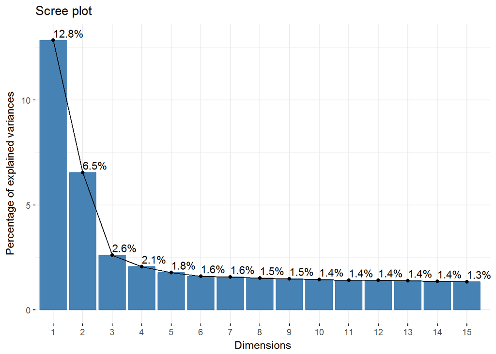

```r
fviz_eig(resMFA, choice="variance", ncp=15, addlabels=TRUE, ylim=c(0,13), xlim=c(1,15.2))
```

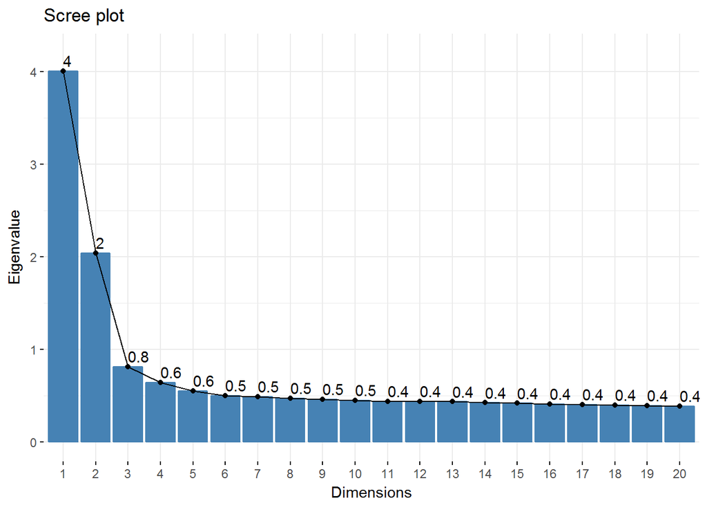

```r
fviz_eig(resMFA, choice="eigenvalue", ncp=20, addlabels=TRUE, ylim=c(0,4.2))
```

On garde les 43 premières composantes principales, ce qui permet de conserver 70% de l’inertie initiale du jeu de données.

Si on veut étudier les premiers axes de l’AFM, on peut regarder principalement les 4-5 premiers axes.

### Etude de l’AFM

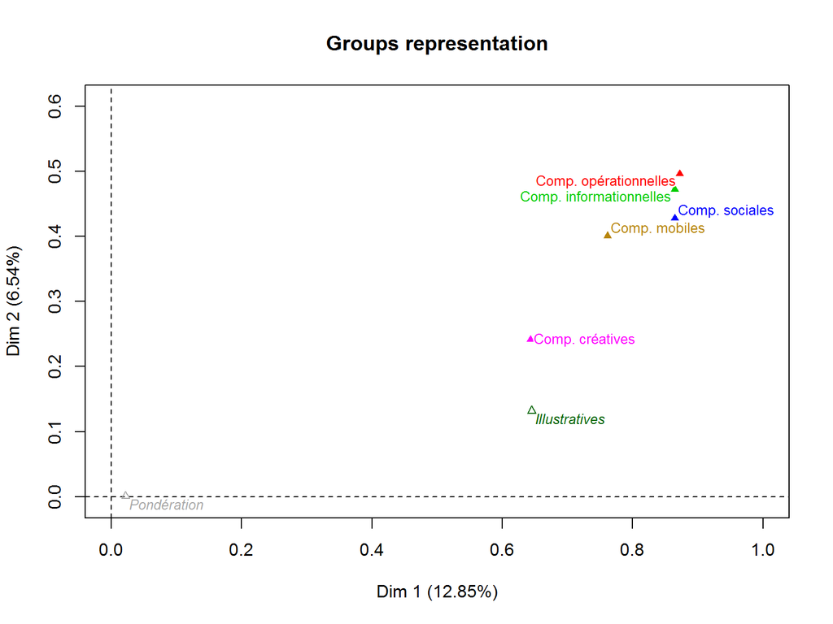

```r
# Groupes
#--------------------
# Représentation des groupes sur le 1er plan factoriel
plot(resMFA, choix=c("group"), shadowtext=TRUE, cex=0.8, ylim=c(0,0.6))
```

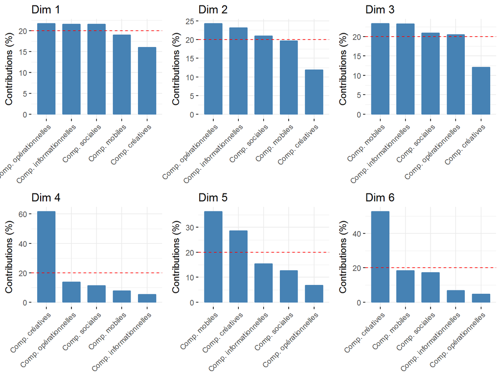

```r
#fviz_mfa_var(resMFA, "group")

# Contribution des groupes aux 6 premières dimensions
p1=fviz_contrib(resMFA, "group", axes=1) + ggtitle("Dim 1")
p2=fviz_contrib(resMFA, "group", axes=2) + ggtitle("Dim 2")
p3=fviz_contrib(resMFA, "group", axes=3) + ggtitle("Dim 3")
p4=fviz_contrib(resMFA, "group", axes=4) + ggtitle("Dim 4")
p5=fviz_contrib(resMFA, "group", axes=5) + ggtitle("Dim 5")
p6=fviz_contrib(resMFA, "group", axes=6) + ggtitle("Dim 6")
grid.arrange(p1,p2,p3,p4,p5,p6, ncol=3, nrow=2)
```

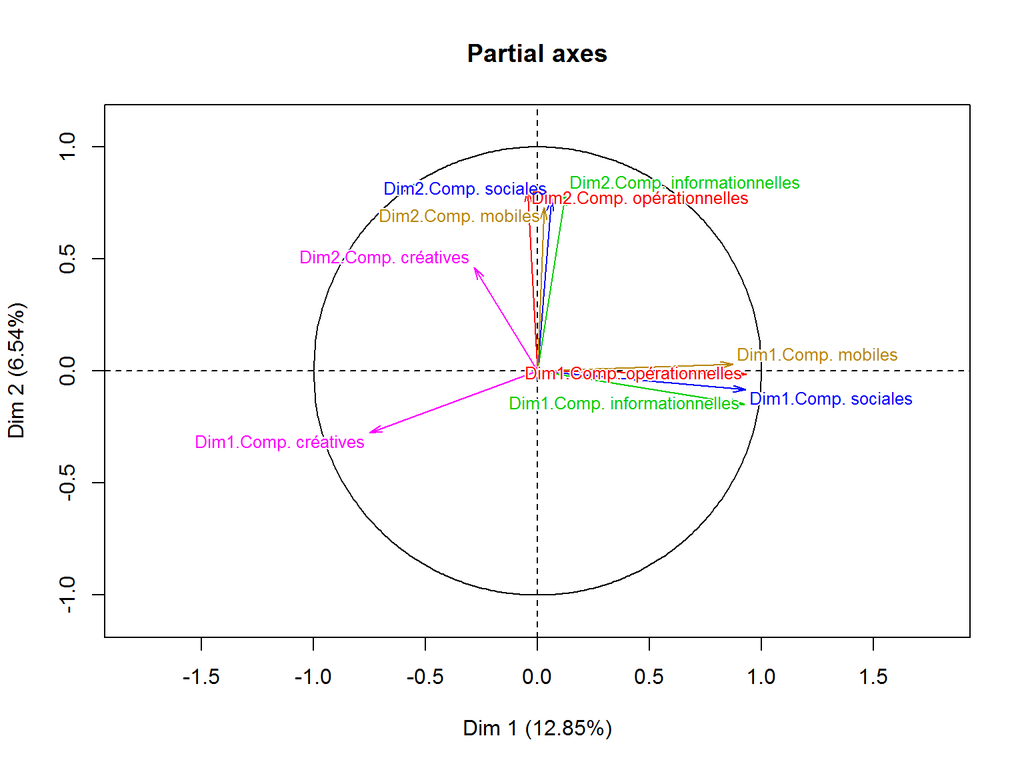

```r
# Axes partiels
#--------------------
# Représentation des axes partiels sur les axes de l'AFM
plot(resMFA, choix=c("axes"), cex=0.8, select="contrib 10", autoLab="auto", shadowtext=TRUE, legend=list(plot=FALSE))
```

```r
#fviz_mfa_axes(resMFA, select.axes=list(contrib=10), repel=TRUE) + theme(legend.position='none')



# # Qualité de représentation (cos2) des modalités des variables sur les axes factoriels
# var=get_mfa_var(resMFA, "quali.var")
# library(corrplot)
# corrplot(var$cos2, is.corr=FALSE)
# a=corrplot(var$contrib, is.corr=FALSE)
# corrplot(t(a))
```

La projection des groupes dans le premier plan factoriel montre une proximité importante entre les groupes “Compétences opérationnelles”, “informationnelles”, “sociales” et “mobiles”. Les compétences créatives quant à elles apparaissent relativement éloignées des 4 groupes précedemment cités. Cet éloignement traduit un rôle spécifique joué par les compétences créatives dans les profils de compétences des répondants. A l’inverse, la proximité constatée entre les 4 autres groupes traduit des profils/réponses assez proches d’un type de compétences à l’autre.

Ces 4 groupes de compétence ont des coordonnées positives élevées sur le plan factoriel 1-2 (1er quadrant) et contribuent fortement à la construction des axes 1, 2 et 3. Les compétences créatives ont une contribution moins forte sur ces axes. En revanche, elles vont très fortement contribuer aux axes 4, 5 et 6 et définir quasiment à elles seules les axes 4 et 6 (les compétences mobiles sont les principales contributrices de l’axe 5).

La projection des axes partiels sur le premier plan de l’AFM montre que les dimensions 1 (resp. 2) des groupes “Compétences opérationnelles”, “mobiles”, “sociales” et “informationnelles” sont très corrélées positivement à la première (resp. deuxième) dimension de l’AFM. Tandis que la dimension 1 des compétences créatives est assez fortement corrélée négativement à la dimension 1 de l’AFM et que la dimension 2 de ces compétences est moyennement corrélée positivement à la dimension 2 de l’AFM. Ce qui confirme le rôle particulier joué par ce type de compétences dans la compétence numérique globale.

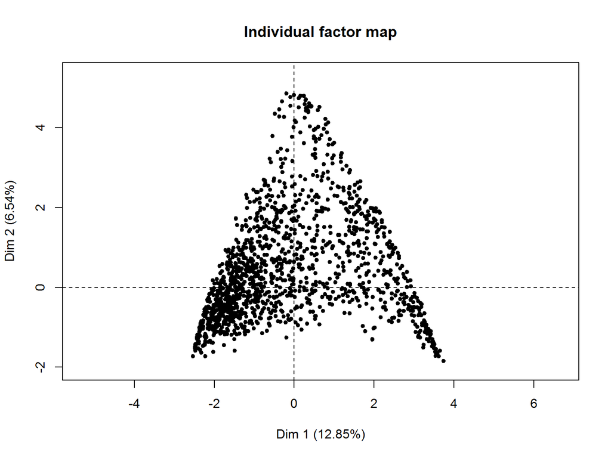

```r
# Individus
#--------------------
# Représentation des individus
plot(resMFA, choix=c("ind"), invisible=("quali"), lab.ind=FALSE)
```

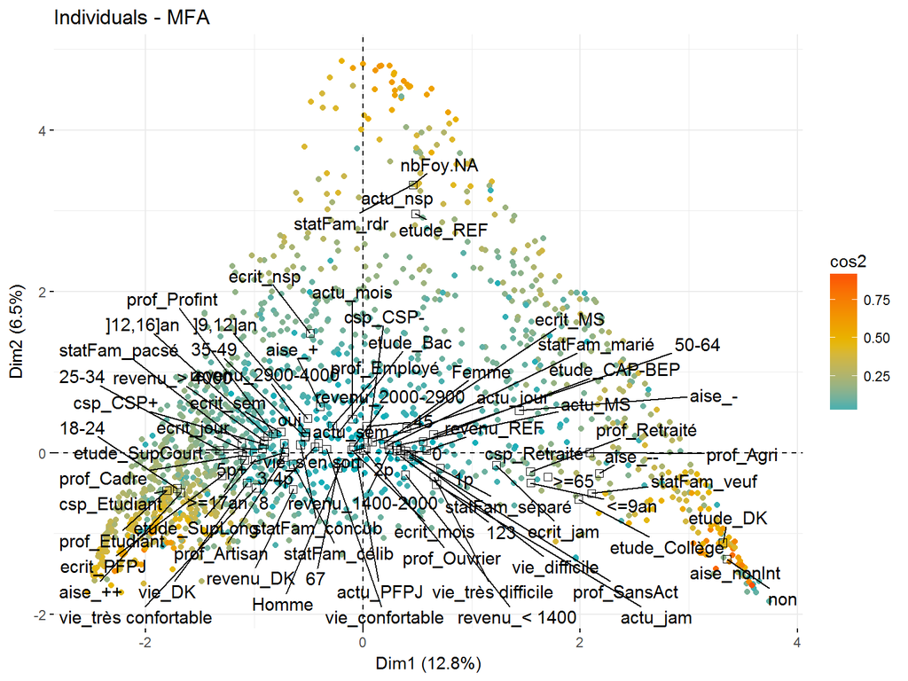

```r
# Représentation des individus colorés en fonction de leur cos2
fviz_mfa_ind(resMFA, col.ind="cos2", gradient.cols=c("#00AFBB","#E7B800","#FC4E07"), geom="point", label="none", invisible=c("var","quali.sup","quanti.sup"), repel=TRUE)
```

La projection des individus et des variables illustratives sur le premier plan factoriel laisse entrevoir une opposition le long de l’axe 1 entre les “jeunes, étudiants, très à l’aise avec Internet” situés sur la gauche du graphique et les “personnes âgées, retraités, pas à l’aise avec Internet voire non-internautes” situés sur la droite du graphique.

L’axe 1 présente également un gradient de compétences, des individus les plus compétents à gauche du graphique vers les individus les moins compétents à droite.

L’axe 3 oppose les plutôt compétents (à gauche) aux plutôt pas compétents (à droite).

L’axe 4 oppose les très compétents créatifs (en haut et en particulier pour les compétences “savoir créer un site web” et “savoir programmer dans un langage informatique”) aux moins compétents (en bas).

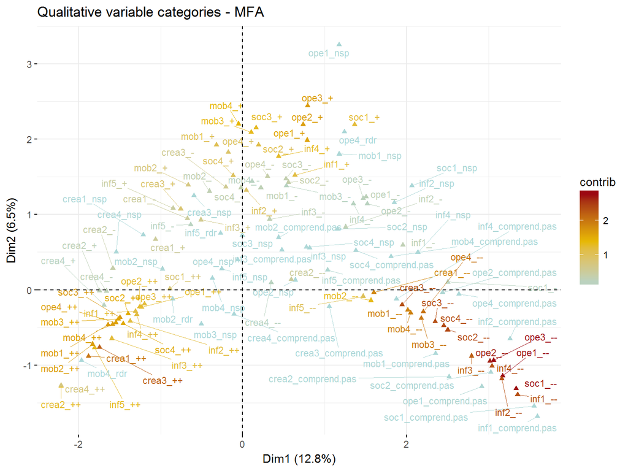

```r
# Modalités
#--------------------
# Représentation des modalités
fviz_mfa_var(resMFA, "quali.var", axes=c(1,2), col.var="contrib", gradient.cols=c("#abd7d8","#E7B800","#9b0312"), repel=TRUE, labelsize=3)
```

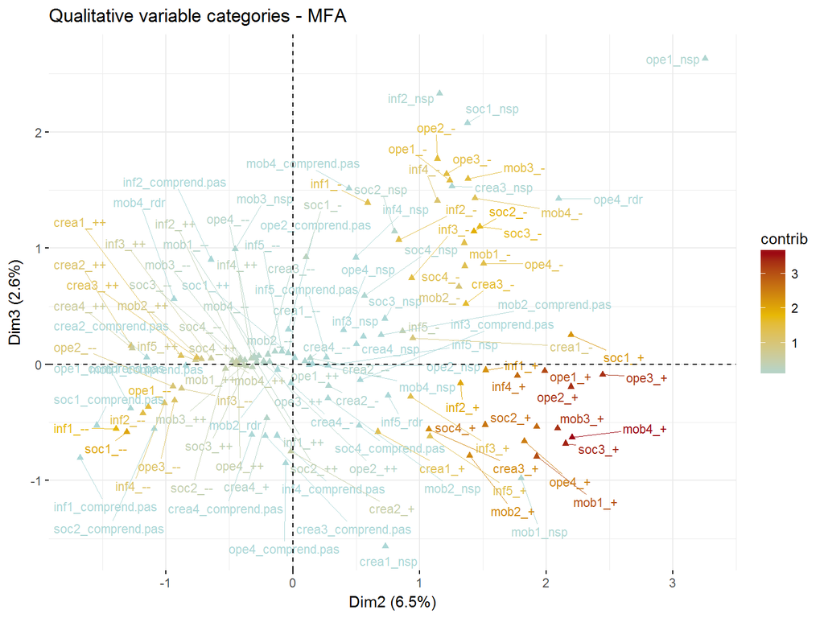

```r
fviz_mfa_var(resMFA, "quali.var", axes=c(2,3), col.var="contrib", gradient.cols=c("#abd7d8","#E7B800","#9b0312"), repel=TRUE, labelsize=3)
```

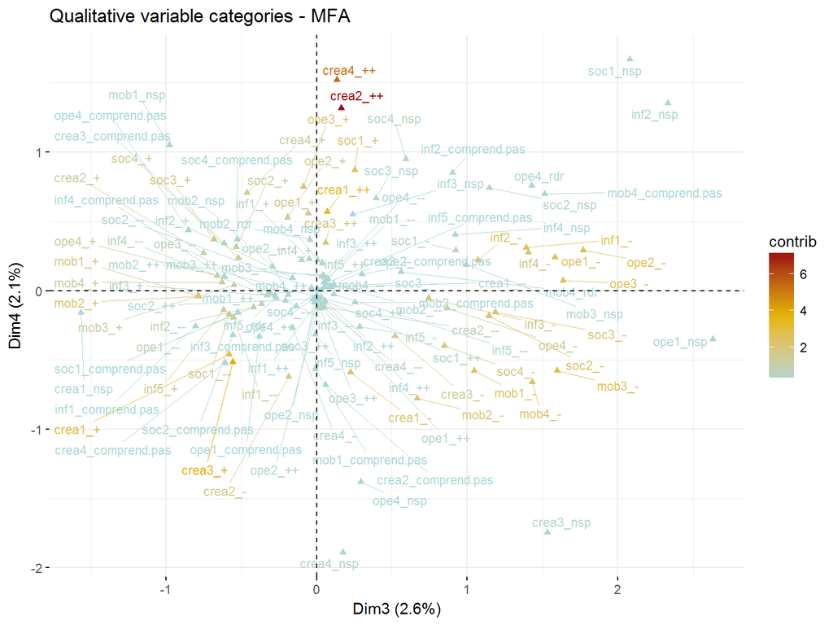

```r
fviz_mfa_var(resMFA, "quali.var", axes=c(3,4), col.var="contrib", gradient.cols=c("#abd7d8","#E7B800","#9b0312"), repel=TRUE, labelsize=3)
```

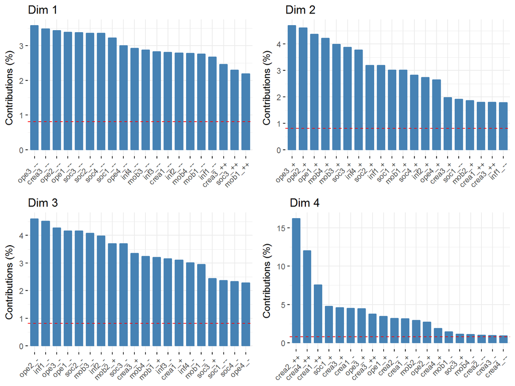

```r
# Contributions des modalités aux 4 premières dimensions
p1=fviz_contrib(resMFA, choice="quali.var", axes=1, top=20, palette="jco") + ggtitle("Dim 1")
p2=fviz_contrib(resMFA, choice="quali.var", axes=2, top=20, palette="jco") + ggtitle("Dim 2")
p3=fviz_contrib(resMFA, choice="quali.var", axes=3, top=20, palette="jco") + ggtitle("Dim 3")
p4=fviz_contrib(resMFA, choice="quali.var", axes=4, top=20, palette="jco") + ggtitle("Dim 4")
grid.arrange(p1,p2,p3,p4, ncol=2, nrow=2)
```

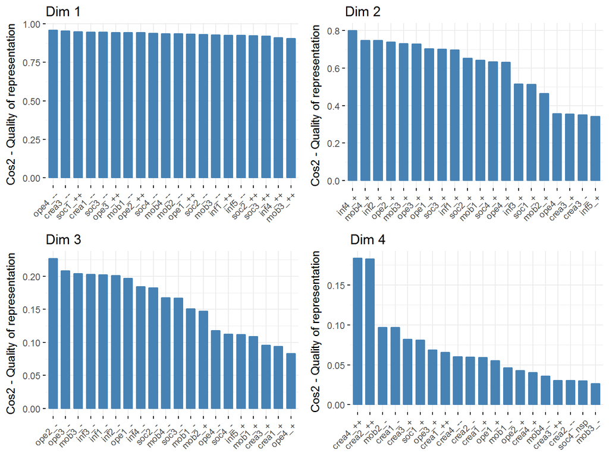

```r
# Cos2 des modalités sur les 4 premières dimensions
p1=fviz_cos2(resMFA, choice="quali.var", axes=1, top=20, palette="jco") + ggtitle("Dim 1")
p2=fviz_cos2(resMFA, choice="quali.var", axes=2, top=20, palette="jco") + ggtitle("Dim 2")
p3=fviz_cos2(resMFA, choice="quali.var", axes=3, top=20, palette="jco") + ggtitle("Dim 3")
p4=fviz_cos2(resMFA, choice="quali.var", axes=4, top=20, palette="jco") + ggtitle("Dim 4")
grid.arrange(p1,p2,p3,p4, ncol=2, nrow=2)
```

Une analyse plus détaillée des contributions des modalités des variables actives de l’AFM à la construction des premiers axes montre que :

- Axe 1
  - contribution positive : les modalités “Cela ne vous ressemble pas du tout” de nombreuses variables parmi lesquelles les 4 compétences opérationnelles, crea3, les 4 sociales, les 4 informationnelles, mob3, mob4, mob1, etc.
  - contribution négative : les modalités “Cela vous ressemble beaucoup” des variables crea3, soc3, mob1, etc.
- Axe 2
  - contribution positive : les modalités “Cela vous ressemble plutôt bien” de nombreuses variables parmi lesquelles les 4 compétences opérationnelles, les 4 mobiles, les 4 sociales, inf4, inf1, inf2, etc.
  - contribution négative : les modalités “Cela vous ressemble beaucoup” ou “Cela ne vous ressemble pas du tout” des variables crea3, crea1, soc1, inf1, etc.
- Axe 3
  - contribution positive : les modalités “Cela vous ressemble assez peu” de nombreuses variables parmi lesquelles les 4 compétences opérationnelles, soc2, inf1, inf2, soc3, mob3, etc.
  - contribution négative : les modalités “Cela vous ressemble plutôt bien” des variables mob2, crea3, mob1, crea1, soc3, etc.
- Axe 4
  - contribution positive : les modalités “Cela vous ressemble beaucoup” des variables de compétences créatives.
  - contribution négative : les modalités “Cela vous ressemble plutôt bien” et “Cela vous ressemble assez peu” des variables de compétences créatives, soc1, ope3, ope1, mob2, mob1, etc.

### Classification ascendante hiérarchique sur le résultat de l’AFM

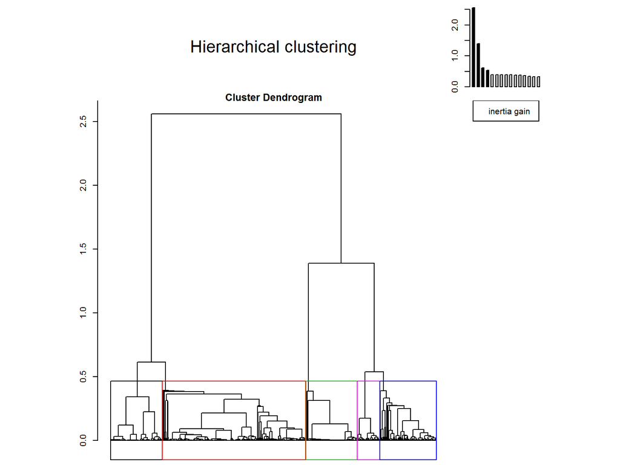

```r
#resHCPC=HCPC(resMFA)
nbClasse=5
# partition en 5 ok un peu global -> sans doute la plus optimale / claire
# 6 ok (distingue les crea++ en cl1, notamment crea4++ coder),
# 7 ok commence à être fin (distingue les - et les -- chez les internautes),
# 8 trop fin (sépare les crea4++ et +), 9 trop fin (même séparation que pour 8 au niveau des crea)
resHCPC=HCPC(resMFA, nb.clust=nbClasse, graph=FALSE)
# resHCPC=HCPC(resMFA,nb.clust=9, graph=FALSE)

# Dendrogramme
plot(resHCPC, choice="tree", labels=FALSE)
```

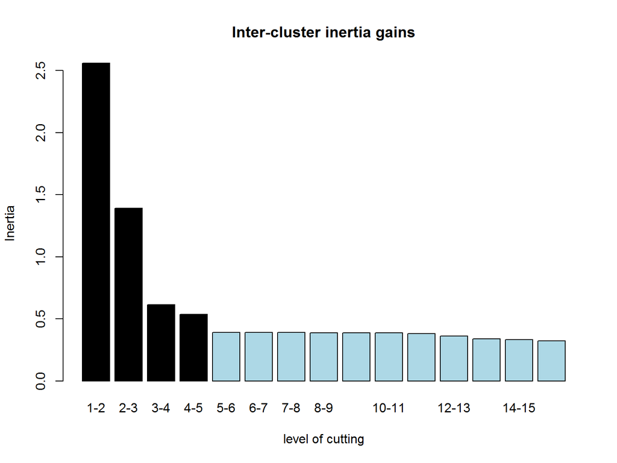

```r
# Nb de classes
plot(resHCPC, choice="bar")
```

```r
skillClust=resHCPC$data.clust
skillClust$poids=as.numeric(as.character(skillClust$poids))
# Répartition par classe
freq(wtd.table(skillClust$clust, weights=skillClust$poids))
```

```
##       n    % val%
## 1 367.6 19.6 19.6
## 2 669.8 35.6 35.6
## 3 214.9 11.4 11.4
## 4 310.8 16.5 16.5
## 5 315.9 16.8 16.8
```

```r
#catdes(skillClust,38)

# # Description des classes
#
# head(round(catdes(skillClust,38,proba=0.01,row.w=skillClust$poids)$category$`1`,2),45)
# head(round(catdes(skillClust,38,proba=0.01,row.w=skillClust$poids)$category$`2`,2),45)
# head(round(catdes(skillClust,38,proba=0.01,row.w=skillClust$poids)$category$`3`,2),45)
# head(round(catdes(skillClust,38,proba=0.01,row.w=skillClust$poids)$category$`4`,2),45)
# head(round(catdes(skillClust,38,proba=0.01,row.w=skillClust$poids)$category$`5`,2),45)
# head(round(catdes(skillClust,38,proba=0.01,row.w=skillClust$poids)$category$`6`,2),45)
# head(round(catdes(skillClust,38,proba=0.01,row.w=skillClust$poids)$category$`7`,2),45)
# head(round(catdes(skillClust,38,proba=0.01,row.w=skillClust$poids)$category$`8`,2),45)
# head(round(catdes(skillClust,38,proba=0.01,row.w=skillClust$poids)$category$`9`,2),45)
```

Le dendrogramme laisse deviner 5 classes naturelles. Ce choix est confirmé par le saut d’inertie présent entre le passage de 4 à 5 classes et le passage de 5 à 6 classes.

Les classes obtenues présentent des effectifs allant de 215 répondants (soit 11% de la population) pour la plus petite à 670 répondants (soit 36%) pour la plus grande.

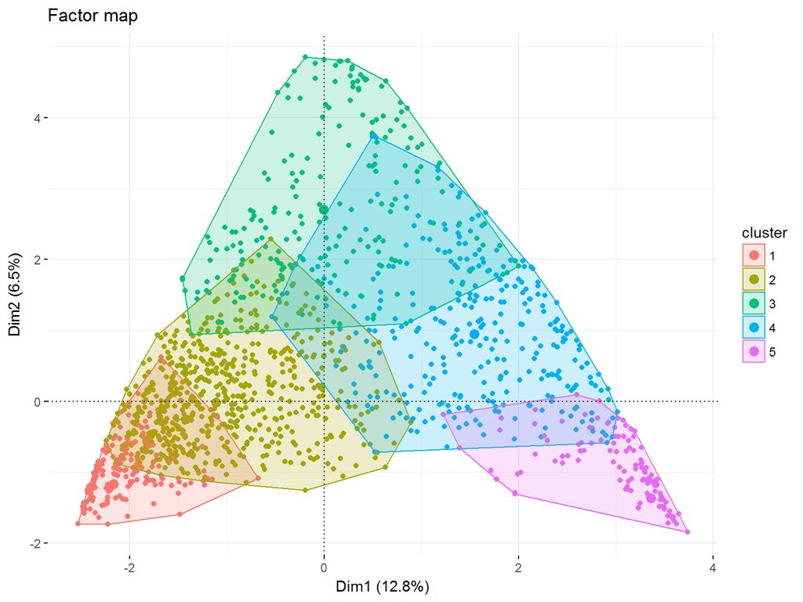

```r
# Représentation des classes sur les premiers plans factoriels

# plot(resHCPC, choice="map", ind.names=FALSE, draw.tree=FALSE, axes=c(1,2))
# plot(resHCPC, choice="map", ind.names=FALSE, draw.tree=FALSE, axes=c(2,3))
# plot(resHCPC, choice="map", ind.names=FALSE, draw.tree=FALSE, axes=c(3,4))
# plot(resHCPC, choice="map", ind.names=FALSE, draw.tree=FALSE, axes=c(4,5))

fviz_cluster(resHCPC, repel=FALSE, shape=16, ellipse=TRUE, geom="point",
             ggtheme=theme_minimal(), main="Factor map") +
  geom_vline(xintercept=0, linetype="dotted") + geom_hline(yintercept=0, linetype="dotted")
```

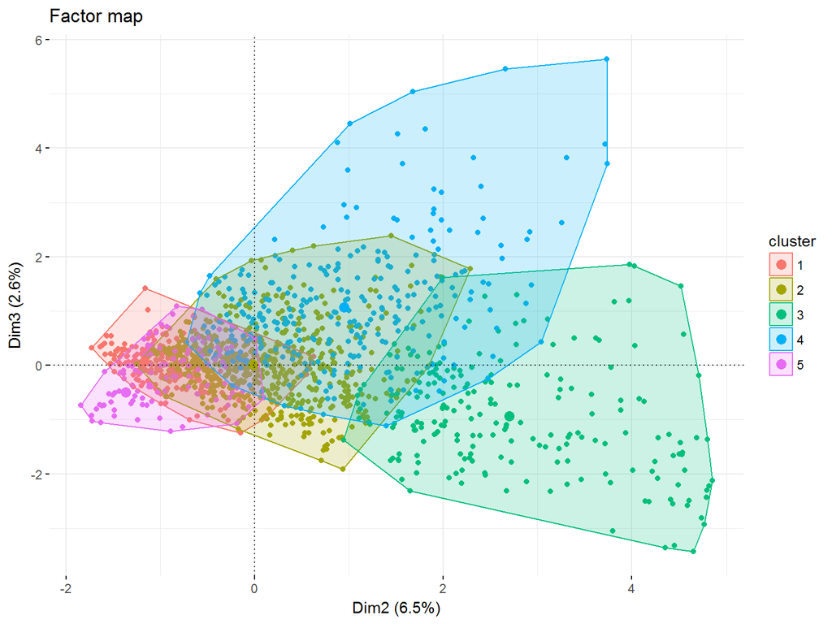

```r
fviz_cluster(resHCPC, repel=FALSE, shape=16, ellipse=TRUE, geom="point",
             ggtheme=theme_minimal(), main="Factor map", axes=c(2,3)) +
  geom_vline(xintercept=0, linetype="dotted") + geom_hline(yintercept=0, linetype="dotted")
```

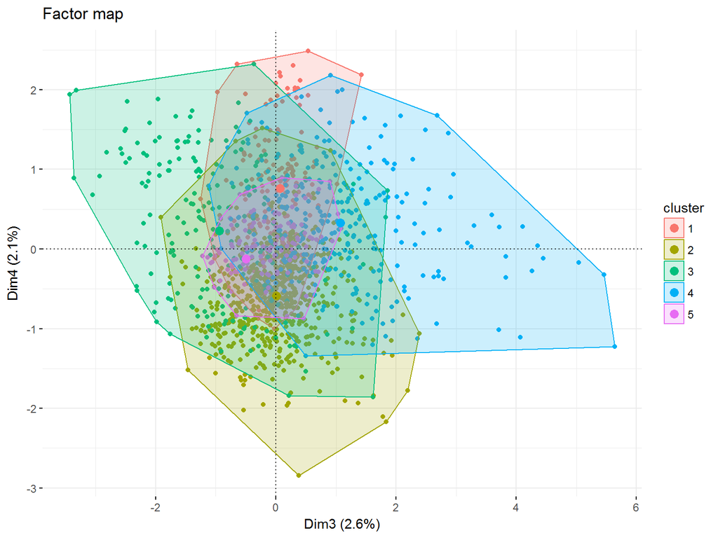

```r
fviz_cluster(resHCPC, repel=FALSE, shape=16, ellipse=TRUE, geom="point",
             ggtheme=theme_minimal(), main="Factor map", axes=c(3,4)) +
  geom_vline(xintercept=0, linetype="dotted") + geom_hline(yintercept=0, linetype="dotted")
```

```r
# library(tibble)
# a1=rownames_to_column(skillClust)
# a2=rownames_to_column(data[,c("WIP.outil_4","WIP.outil_5")])
# a=left_join(a1,a2,by="rowname")
# round(prop.table(table(a$clust,a$WIP.outil_5),1)*100)
```

La projection des classes sur le plan 1-2 laisse apparaître des classes plutôt bien séparées, laissant augurer des profils de compétences distincts.

## Description des classes (signif à 1%)

### Classe 1

```
##                          Cla/Mod Mod/Cla Global p.value v.test
## crea1=crea1_++             71.13   90.38  24.86    0.00  30.96
## crea3=crea3_++             56.14   96.01  33.46    0.00  28.82
## crea2=crea2_++             96.70   49.04   9.92    0.00  24.92
## mob1=mob1_++               42.28   96.62  44.71    0.00  23.91
## inf5=inf5_++               54.87   77.39  27.60    0.00  22.75
## ope4=ope4_++               39.34   96.86  48.17    0.00  22.66
## mob4=mob4_++               39.95   95.40  46.72    0.00  22.41
## mob2=mob2_++               50.48   81.10  31.43    0.00  22.23
## soc3=soc3_++               36.91   97.93  51.91    0.00  21.91
## soc2=soc2_++               35.79   98.64  53.92    0.00  21.72
## mob3=mob3_++               37.90   96.34  49.74    0.00  21.68
## inf3=inf3_++               46.68   79.15  33.17    0.00  20.43
## inf1=inf1_++               33.60   98.42  57.30    0.00  20.24
## soc4=soc4_++               37.78   91.15  47.20    0.00  19.79
## inf4=inf4_++               33.40   97.43  57.08    0.00  19.55
## inf2=inf2_++               36.77   91.70  48.79    0.00  19.42
## ope2=ope2_++               31.31   99.48  62.16    0.00  19.36
## ope1=ope1_++               31.24   99.21  62.14    0.00  19.12
## ope3=ope3_++               30.17   99.76  64.70    0.00  18.71
## aise=aise_++               47.47   67.92  28.00    0.00  18.13
## crea4=crea4_++             93.26   26.39   5.54    0.00  16.96
## soc1=soc1_++               26.21  100.00  74.66    0.00  15.43
## internaute=oui             22.67  100.00  86.30    0.00  10.79
## age=18-24                  49.57   26.97  10.65    0.00  10.17
## ecrit=ecrit_PFPJ           45.12   30.33  13.15    0.00  10.00
## csp=csp_Etudiant           55.34   19.64   6.95    0.00   9.37
## prof=prof_Etudiant         55.34   19.64   6.95    0.00   9.37
## crea4=crea4_+              60.84   12.47   4.01    0.00   8.09
## etude=etude_SupLong        31.99   36.41  22.27    0.00   6.97
## crea2=crea2_+              49.54   13.55   5.35    0.00   6.95
## debInt=>=17an              32.45   34.65  20.89    0.00   6.83
## crea4=crea4_-              46.48   14.30   6.02    0.00   6.78
## statFam=statFam_célib      31.38   35.65  22.23    0.00   6.58
## sexe=Homme                 25.57   63.32  48.44    0.00   6.38
## csp=csp_CSP+               29.22   41.45  27.76    0.00   6.27
## prof=prof_Cadre            35.66   17.60   9.66    0.00   5.43
## ecrit=ecrit_jour           30.83   22.68  14.39    0.00   4.76
## age=25-34                  29.74   24.72  16.27    0.00   4.69
## etude=etude_SupCourt       28.86   25.28  17.14    0.00   4.44
## nbFoy=3-4p                 25.58   41.74  31.92    0.00   4.35
## vie=vie_très confortable   45.09    6.21   2.69    0.00   4.17
## agglo=8                    27.95   23.66  16.57    0.00   3.94
## revenu=revenu_DK           43.11    5.64   2.56    0.00   3.85
## crea2=crea2_-              30.11   13.61   8.85    0.00   3.41
## nbFoy=5p+                  30.87   12.91   8.18    0.00   3.39
## prof=prof_Artisan          34.02    6.15   3.54    0.00   2.96
## actu=actu_PFPJ             21.98   55.97  49.81    0.01   2.64
```

### Classe 2

```
##                        Cla/Mod Mod/Cla Global p.value v.test
## ope2=ope2_++             53.99   94.14  62.16    0.00  23.07
## ope3=ope3_++             52.79   95.82  64.70    0.00  23.06
## ope1=ope1_++             53.64   93.51  62.14    0.00  22.43
## inf4=inf4_++             54.90   87.91  57.08    0.00  21.07
## soc1=soc1_++             47.27   99.00  74.66    0.00  20.77
## inf1=inf1_++             53.79   86.46  57.30    0.00  19.82
## soc3=soc3_++             54.61   79.52  51.91    0.00  18.30
## soc2=soc2_++             52.64   79.62  53.92    0.00  17.01
## mob3=mob3_++             54.08   75.46  49.74    0.00  16.80
## mob4=mob4_++             54.15   70.96  46.72    0.00  15.78
## ope4=ope4_++             53.47   72.27  48.17    0.00  15.73
## soc4=soc4_++             53.70   71.11  47.20    0.00  15.56
## inf2=inf2_++             52.64   72.06  48.79    0.00  15.21
## internaute=oui           41.18   99.70  86.30    0.00  14.95
## mob1=mob1_++             52.28   65.57  44.71    0.00  13.56
## crea3=crea3_+            62.55   32.34  18.43    0.00  11.38
## crea1=crea1_+            63.79   28.26  15.79    0.00  10.71
## crea1=crea1_-            59.73   23.05  13.75    0.00   8.47
## aise=aise_+              45.56   58.55  45.82    0.00   8.21
## inf3=inf3_++             47.23   43.95  33.17    0.00   7.29
## mob2=mob2_++             47.63   41.99  31.43    0.00   7.22
## debInt=]12,16]an         49.88   28.56  20.41    0.00   6.35
## inf3=inf3_+              46.68   38.10  29.09    0.00   6.29
## age=25-34                50.74   23.15  16.27    0.00   5.87
## aise=aise_++             46.07   36.19  28.00    0.00   5.78
## crea4=crea4_--           38.10   89.67  83.90    0.00   5.20
## nbFoy=3-4p               43.32   38.79  31.92    0.00   4.72
## debInt=>=17an            45.54   26.69  20.89    0.00   4.54
## crea2=crea2_--           38.43   81.65  75.73    0.00   4.51
## etude=etude_SupLong      44.82   28.00  22.27    0.00   4.46
## ecrit=ecrit_jour         47.67   19.25  14.39    0.00   4.42
## csp=csp_CSP+             43.39   33.79  27.76    0.00   4.25
## inf5=inf5_+              47.10   18.64  14.10    0.00   4.15
## crea2=crea2_-            50.78   12.60   8.85    0.00   4.12
## prof=prof_Profint        46.89   19.16  14.56    0.00   4.07
## inf5=inf5_-              49.33   12.79   9.24    0.00   3.90
## inf5=inf5_++             42.56   32.95  27.60    0.00   3.84
## etude=etude_SupCourt     45.13   21.70  17.14    0.00   3.81
## statFam=statFam_pacsé    54.92    7.32   4.75    0.00   3.80
## mob2=mob2_-              50.38    9.68   6.85    0.00   3.54
## age=35-49                41.83   30.65  26.12    0.00   3.25
## revenu=revenu_> 4000     47.49   11.14   8.36    0.00   3.25
## agglo=67                 40.93   34.77  30.28    0.00   3.14
## crea3=crea3_-            46.18   12.51   9.65    0.00   3.12
## prof=prof_Employé        43.24   20.51  16.91    0.00   3.00
## csp=csp_CSP-             39.50   46.37  41.85    0.00   2.99
## statFam=statFam_concub   43.81   17.37  14.13    0.00   2.89
## age=18-24                44.43   13.27  10.65    0.01   2.72
## ecrit=ecrit_sem          42.45   18.91  15.88    0.01   2.71
```

### Classe 3

```
##                   Cla/Mod Mod/Cla Global p.value v.test
## mob4=mob4_+         64.38   69.45  12.34    0.00  21.86
## mob3=mob3_+         60.50   68.71  12.99    0.00  21.17
## mob1=mob1_+         58.16   58.83  11.57    0.00  18.60
## soc3=soc3_+         58.93   56.69  11.00    0.00  18.35
## ope2=ope2_+         49.84   58.77  13.48    0.00  17.16
## inf4=inf4_+         40.45   67.96  19.21    0.00  16.94
## ope1=ope1_+         43.08   58.59  15.55    0.00  15.83
## ope3=ope3_+         49.88   48.20  11.05    0.00  15.19
## soc2=soc2_+         48.67   48.28  11.34    0.00  14.99
## soc4=soc4_+         39.85   56.19  16.13    0.00  14.69
## inf2=inf2_+         31.63   69.22  25.02    0.00  14.68
## inf1=inf1_+         33.81   65.15  22.03    0.00  14.63
## mob2=mob2_+         43.41   51.79  13.64    0.00  14.58
## ope4=ope4_+         47.34   46.20  11.16    0.00  14.25
## inf3=inf3_+         25.47   64.79  29.09    0.00  11.54
## inf5=inf5_+         33.27   41.04  14.10    0.00  10.48
## aise=aise_+         19.57   78.42  45.82    0.00  10.25
## crea3=crea3_+       28.70   46.26  18.43    0.00  10.00
## soc1=soc1_+         40.43   29.10   8.23    0.00   9.91
## internaute=oui      13.06   98.55  86.30    0.00   6.67
## crea1=crea1_-       24.23   29.14  13.75    0.00   6.39
## crea3=crea3_-       27.67   23.36   9.65    0.00   6.35
## crea1=crea1_+       22.71   31.35  15.79    0.00   6.03
## soc4=soc4_-         25.53   15.20   6.81    0.00   4.69
## mob2=mob2_-         25.55   15.30   6.85    0.00   4.65
## debInt=]9,12]an     17.36   36.89  24.30    0.00   4.33
## inf5=inf5_-         20.83   16.83   9.24    0.00   3.71
## ope4=ope4_-         21.75   12.90   6.78    0.00   3.54
## ecrit=ecrit_sem     17.39   24.15  15.88    0.00   3.38
## prof=prof_Employé   17.12   25.31  16.91    0.00   3.25
## inf3=inf3_-         17.26   21.99  14.56    0.00   3.06
## age=35-49           15.07   34.42  26.12    0.00   2.87
## mob1=mob1_nsp       73.93    1.33   0.21    0.01   2.77
## etude=etude_REF     71.99    1.31   0.21    0.01   2.77
## mob1=mob1_-         20.46   10.93   6.11    0.01   2.75
## etude=etude_Bac     15.42   26.57  19.70    0.01   2.59
```

La classe 3 est la plus petite avec environ 11% des répondants. C’est la classe des individus ayant de plutôt bonnes compétences dans tous les types abordés, même s’ils sont globalement moins à l’aise dans les compétences créatives. 35-49 ans, employé, à l’aise avec Internet, ancienneté 9-12 ans, internautes (99%), écrit assez fréquent, étude niveau bac.

### Classe 4

```
##                        Cla/Mod Mod/Cla Global p.value v.test
## mob2=mob2_--             31.06   85.02  45.27    0.00  15.79
## mob1=mob1_--             34.20   77.13  37.30    0.00  15.74
## crea1=crea1_--           30.20   83.18  45.55    0.00  14.99
## inf2=inf2_-              63.49   33.81   8.81    0.00  14.42
## mob4=mob4_--             33.10   72.77  36.37    0.00  14.32
## crea3=crea3_--           32.11   74.17  38.21    0.00  14.18
## inf1=inf1_+              41.18   54.85  22.03    0.00  14.03
## aise=aise_-              55.30   36.71  10.98    0.00  13.77
## mob3=mob3_--             33.71   67.73  33.23    0.00  13.76
## soc3=soc3_--             33.73   63.54  31.16    0.00  12.91
## crea2=crea2_--           21.55   98.66  75.73    0.00  12.40
## inf1=inf1_-              65.80   23.59   5.93    0.00  12.07
## ope4=ope4_--             31.55   64.13  33.62    0.00  12.04
## ope1=ope1_-              79.79   17.98   3.73    0.00  11.97
## inf3=inf3_-              42.83   37.72  14.56    0.00  11.33
## inf5=inf5_--             27.66   71.92  43.00    0.00  11.32
## ope3=ope3_-              78.26   16.88   3.57    0.00  11.26
## ope1=ope1_+              40.98   38.53  15.55    0.00  11.11
## soc4=soc4_--             31.27   53.56  28.33    0.00  10.26
## inf4=inf4_+              36.15   41.98  19.21    0.00  10.23
## ope2=ope2_-              72.07   14.34   3.29    0.00   9.95
## inf4=inf4_-              67.54   15.85   3.88    0.00   9.86
## soc2=soc2_-              51.62   20.77   6.66    0.00   9.51
## soc1=soc1_+              47.38   23.58   8.23    0.00   9.35
## soc2=soc2_--             29.76   49.08  27.28    0.00   9.06
## ope3=ope3_+              41.12   27.47  11.05    0.00   8.96
## crea4=crea4_--           19.26   97.69  83.90    0.00   8.49
## ope2=ope2_+              35.39   28.85  13.48    0.00   8.00
## soc3=soc3_-              49.21   16.36   5.50    0.00   8.00
## inf2=inf2_+              28.52   43.14  25.02    0.00   7.69
## ope4=ope4_-              42.49   17.42   6.78    0.00   7.20
## age=>=65                 28.13   37.60  22.11    0.00   6.87
## mob3=mob3_-              50.07   10.95   3.62    0.00   6.49
## csp=csp_Retraité         26.24   37.19  23.45    0.00   6.03
## prof=prof_Retraité       26.24   37.19  23.45    0.00   6.03
## ecrit=ecrit_jam          23.40   47.09  33.29    0.00   5.49
## internaute=oui           18.15   94.71  86.30    0.00   5.02
## mob4=mob4_-              41.37    8.94   3.57    0.00   4.98
## soc2=soc2_nsp            84.20    3.24   0.64    0.00   4.97
## mob1=mob1_-              34.55   12.76   6.11    0.00   4.92
## soc1=soc1_-              47.62    6.67   2.32    0.00   4.84
## soc4=soc4_-              32.94   13.56   6.81    0.00   4.69
## age=50-64                23.25   34.94  24.86    0.00   4.42
## etude=etude_CAP-BEP      22.45   36.21  26.68    0.00   4.11
## inf5=inf5_comprend.pas   34.06    9.76   4.74    0.00   4.05
## ope2=ope2_--             23.63   29.24  20.47    0.00   4.05
## debInt=<=9an             21.28   44.26  34.40    0.00   4.00
## statFam=statFam_marié    20.75   48.68  38.81    0.00   3.82
## ope2=ope2_comprend.pas   68.40    2.24   0.54    0.00   3.65
## soc4=soc4_nsp            47.71    3.46   1.20    0.00   3.47
## nbFoy=2p                 20.66   41.68  33.36    0.00   3.40
## inf3=inf3_nsp            54.65    2.27   0.69    0.00   3.02
## inf4=inf4_nsp           100.00    0.99   0.16    0.00   2.84
## crea3=crea3_-            23.43   13.67   9.65    0.01   2.63
```

La classe 4 contient environ 16% de la population. C’est la classe des individus ayant des compétences faibles ou très faibles dans la plupart des compétences abordées, et notamment mobiles et créatives. Ils se sentent néanmoins assez à l’aise sur quelques points comme la recherche d’informations en ligne, l’utilisation de bons mots-clés, rechercher des itinéraires en ligne, ouvrir un fichier téléchargé, envoyer un email et y joindre un document, se connecter à un réseau wifi. Bref, quelques usages assez basiques. 95% de ces individus sont internautes. 50-64 ans et >=65 ans, retraités, assez peu à l’aise avec Internet, CAP-BEP, mariés, 2personnes dans le foyer, ancienneté < 9 ans

### Classe 5

```
##                        Cla/Mod Mod/Cla Global p.value v.test
## ope3=ope3_--             78.64   96.72  20.68    0.00  34.27
## ope1=ope1_--             85.11   92.46  18.27    0.00  34.09
## inf2=inf2_--             86.60   88.65  17.21    0.00  33.20
## inf1=inf1_--             93.88   81.96  14.68    0.00  32.83
## inf3=inf3_--             72.19   96.06  22.38    0.00  32.62
## inf4=inf4_--             79.04   91.69  19.50    0.00  32.58
## soc1=soc1_--             92.13   80.45  14.68    0.00  31.94
## ope2=ope2_--             73.78   89.80  20.47    0.00  30.77
## aise=aise_nonInt         91.63   74.67  13.70    0.00  30.26
## internaute=non           91.63   74.67  13.70    0.00  30.26
## soc2=soc2_--             57.76   93.71  27.28    0.00  28.14
## soc4=soc4_--             55.73   93.89  28.33    0.00  27.74
## ope4=ope4_--             49.24   98.45  33.62    0.00  27.51
## soc3=soc3_--             51.97   96.29  31.16    0.00  27.43
## mob4=mob4_--             45.04   97.41  36.37    0.00  25.74
## crea3=crea3_--           43.48   98.80  38.21    0.00  25.73
## mob3=mob3_--             47.63   94.14  33.23    0.00  25.28
## mob1=mob1_--             43.77   97.10  37.30    0.00  25.15
## debInt=<=9an             44.55   91.14  34.40    0.00  23.34
## crea1=crea1_--           36.43   98.71  45.55    0.00  22.87
## mob2=mob2_--             35.86   96.57  45.27    0.00  21.62
## inf5=inf5_--             35.80   91.55  43.00    0.00  19.87
## etude=etude_Collège      53.87   44.69  13.95    0.00  15.21
## ecrit=ecrit_jam          35.60   70.47  33.29    0.00  14.98
## age=>=65                 41.94   55.14  22.11    0.00  14.31
## csp=csp_Retraité         39.87   55.60  23.45    0.00  13.80
## prof=prof_Retraité       39.87   55.60  23.45    0.00  13.80
## crea2=crea2_--           22.00   99.07  75.73    0.00  12.81
## crea4=crea4_--           19.89   99.27  83.90    0.00  10.06
## statFam=statFam_veuf     52.90   20.09   6.39    0.00   9.32
## nbFoy=1p                 29.31   46.17  26.48    0.00   8.32
## revenu=revenu_< 1400     28.15   41.52  24.80    0.00   7.19
## soc1=soc1_-              49.96    6.88   2.32    0.00   5.11
## vie=vie_très difficile   30.66   15.06   8.26    0.00   4.55
## vie=vie_difficile        25.79   25.38  16.55    0.00   4.39
## aise=aise_--             50.55    4.52   1.50    0.00   4.04
## ope1=ope1_comprend.pas  100.00    1.55   0.26    0.00   3.82
## etude=etude_CAP-BEP      22.41   35.56  26.68    0.00   3.78
## age=50-64                22.02   32.56  24.86    0.00   3.41
## prof=prof_Agri           49.27    2.54   0.87    0.00   3.02
## statFam=statFam_séparé   23.01   18.67  13.65    0.01   2.77
## agglo=123                22.41   22.29  16.72    0.01   2.76
## nbFoy=2p                 20.02   39.73  33.36    0.01   2.66
```

La classe 5 contient environ 17% des répondants. Ces individus ont des compétences très faibles sur l’ensemble des types de compétences (plus encore que la classe 4). 75% ne sont pas internautes (grosse différence par rapport à la classe 4). >=65 ans, 50-64 ans, retraités, veuf, séparé, 1p dans le foyer ou 2, revenu < 1400€, vie difficile et très difficile, ancienneté < 9 ans, pas du tout à l’aise avec Internet, agriculteurs, étude type collège, CAP-BEP, écrit très rare